# Part A · Captain onboarding health

**Decision:** Where should Supply invest to increase approved captains, and should `CAMP_WA_002` receive five times the budget?

This notebook covers **A1–A4 only**. It uses the five onboarding CSVs and leaves the airport analysis out of scope. Reusable loading, validation, funnel and segment calculations live in `utils.py` and are also used by `app.py`. All numerical findings are recomputed from the raw files; the final cells export the tables, figures, a two-page memo, and a six-slide deck.

**Reading path:** A1 defines the funnel, A2 sizes interventions, A3 evaluates the campaign, and A4 contains the decision brief and ranked actions. The audit and sensitivity checks make the working reviewable.

**Analysis contract, specified before modelling**

- Primary outcome: **A2O within 30 elapsed days of signup**, with every signup in the denominator. Secondary: **R2A within the same 30 days**.
- Primary cohort: **January–May 2026 signups**, five complete signup months with at least 30 days of follow-up at the **2026-06-30 23:59 IST** extraction. June is shown separately; an unfinished journey is not automatically a permanent loss.
- Count a document stage only after its verification pass and all required earlier passes. ERickshaw skips Permit; it does not fail that stage.
- Use event timestamps to reconstruct stages. Do not use snapshot status or `docs_cleared` as historical features.
- Campaign analysis is observational. A difference, even after adjustment, is not a proven incremental effect. Report sampling uncertainty and the remaining identification limits separately.
- Model complexity must serve the decision: compare interpretable logistic models with nonlinear gradient boosting for adjustment sensitivity. Deep learning is not justified by these structured tables, and there are no document images with which to train an OCR model.

```python
from pathlib import Path
import os, json, hashlib, platform, importlib.metadata
from datetime import datetime, timezone
ROOT = Path.cwd()
if not (ROOT / 'Data').exists() and (ROOT.parent / 'Data').exists():
    ROOT = ROOT.parent
assert (ROOT / 'Data' / 'captains.csv').exists(), 'Run from the project directory.'
OUT = ROOT / 'outputs' / 'part_a'
OUT.mkdir(parents=True, exist_ok=True)
os.environ.setdefault('MPLCONFIGDIR', str(ROOT / '.cache' / 'matplotlib'))
os.environ.setdefault('OMP_NUM_THREADS', '2')
os.environ.setdefault('OPENBLAS_NUM_THREADS', '2')

import numpy as np
import pandas as pd
from scipy.stats import norm
import matplotlib.pyplot as plt
import seaborn as sns
from IPython.display import display, Markdown, Image as IPImage
from sklearn.compose import ColumnTransformer
from sklearn.preprocessing import OneHotEncoder, StandardScaler
from sklearn.pipeline import make_pipeline
from sklearn.linear_model import LogisticRegression
from sklearn.ensemble import HistGradientBoostingClassifier
from sklearn.model_selection import StratifiedKFold
from sklearn.metrics import roc_auc_score, brier_score_loss, log_loss
from threadpoolctl import threadpool_limits

SEED = 20260630
from utils import (CUTOFF, COHORT_START, COHORT_END, HORIZON, MONTHS, DOCS,
                   QUALITY_REASONS, FILES, wilson, independent_difference_ci,
                   load_and_audit, build_onboarding_funnel, summarize_segments,
                   transported_rate, load_part_a_results)
pd.set_option('display.max_columns', 18)
pd.set_option('display.max_rows', 40)
pd.set_option('display.float_format', lambda x: f'{x:,.3f}')
sns.set_theme(style='whitegrid', context='notebook', palette='colorblind')
plt.rcParams.update({'figure.dpi': 120, 'savefig.dpi': 180,
                     'axes.spines.top': False, 'axes.spines.right': False})
BLUE, ORANGE, GREEN = '#245B78', '#DF803C', '#26836C'
tables, figures = {}, {}

def show_table(name, frame):
    tables[name] = frame.copy()
    display(frame)

def save_figure(name, fig):
    fig.savefig(OUT / f'{name}.png', bbox_inches='tight')
    figures[name] = str(OUT / f'{name}.png')
    display(IPImage(filename=str(OUT / f'{name}.png')))
    plt.close(fig)
```

## Data audit · preserve the distinction between missing and zero

The CSV timestamps have no timezone suffix. Interpret them as **Asia/Kolkata**, as specified by the extraction statement; do not shift them as though they were UTC. Blank first-order timestamps mean *no first order observed by extraction*. Missing D7/D30 counts are retained, because they may reflect immature windows. Without a data dictionary defining their clock, these aggregate order counts are not used to establish R2A.

An event audit must run before any funnel calculation. The raw files are never overwritten. Unexpected key, timestamp, sequence, or event-domain errors fail execution; known summary/telemetry discrepancies are quantified and their analytical treatment is explicit.

```python
# Shared validation is used by the notebook and the dashboard.
audit = load_and_audit(ROOT / 'Data')
data = audit.data
captains, events, approvals, activation, nudges = [data[n] for n in FILES]
s = audit.captains.copy()
attempts = audit.attempts
manifest = audit.manifest
for name, frame in audit.tables.items():
    show_table(name, frame)
```

|  | file | rows | captains | exact_duplicate_rows | sha256 |
| --- | --- | --- | --- | --- | --- |
| 0 | captains.csv | 25000 | 25000 | 0 | 35381b4eb60222ca2f229c8a0beae998e57d4686f88477... |
| 1 | doc_events.csv | 186282 | 23303 | 0 | b63ebc6d1e7adb018996a59190cfee5c8261360fb3eb47... |
| 2 | approvals.csv | 25000 | 25000 | 0 | ec82ecd5faea4068b46ee77204bb2f856ea5f4bf2de893... |
| 3 | activation.csv | 4206 | 4206 | 0 | 9cd2b914afab7d84967aa54595044fe07d1472943c9dba... |
| 4 | nudges.csv | 16314 | 13667 | 0 | 57ed325bba56278d8a05bd54906b1b433e2a1a46665d23... |

|  | captains | doc_events | approvals | activation | nudges |
| --- | --- | --- | --- | --- | --- |
| captain_id | 0.000 | 0.000 | 0.000 | 0.000 | 0.000 |
| signup_ts | 0.000 | — | — | — | — |
| city | 0.000 | — | — | — | — |
| vehicle_type | 0.000 | — | — | — | — |
| acquisition_channel | 0.000 | — | — | — | — |
| signup_zone_id | 0.000 | — | — | — | — |
| device_tier | 0.000 | — | — | — | — |
| app_language | 0.000 | — | — | — | — |
| age_band | 0.000 | — | — | — | — |
| event_id | — | 0.000 | — | — | — |
| doc_type | — | 0.000 | — | — | — |
| attempt_no | — | 0.000 | — | — | — |
| event_type | — | 0.000 | — | — | — |
| event_ts | — | 0.000 | — | — | — |
| failure_reason | — | 166,510.000 | — | — | — |
| decision_ts | — | — | 20,359.000 | — | — |
| final_status | — | — | 0.000 | — | — |
| last_stage_reached | — | — | 4,393.000 | — | — |
| docs_cleared | — | — | 0.000 | — | — |
| first_order_ts | — | — | — | 102.000 | — |
| orders_d7 | — | — | — | 187.000 | — |
| orders_d30 | — | — | — | 834.000 | — |
| online_hours_d30 | — | — | — | 834.000 | — |
| campaign_id | — | — | — | — | 0.000 |
| channel | — | — | — | — | 0.000 |
| sent_ts | — | — | — | — | 0.000 |
| delivered | — | — | — | — | 0.000 |
| clicked | — | — | — | — | 0.000 |

|  | check | rows_or_captains | treatment |
| --- | --- | --- | --- |
| 0 | Summary docs_cleared disagrees with timestampe... | 451 | Reconstruct from events; do not use summary co... |
| 1 | Clicked=1 but delivered=0 | 457 | Use send assignment as exposure; exclude click... |
| 2 | orders_d7 exceeds orders_d30 (both observed) | 7 | Quarantine aggregate counts from outcome infer... |
| 3 | Uploaded attempts with no verification result ... | 190 | Pending at cutoff, not automatic verification ... |
| 4 | Approved with no first order observed | 102 | No observed activation; do not impute timestam... |

|  | signup_month | final_status | captains |
| --- | --- | --- | --- |
| 0 | 2026-06 | dropped_in_docs | 69 |
| 1 | 2026-06 | in_progress | 382 |

## A1 · A comparable, count-based funnel

**Denominators:** the cumulative funnel uses all January–May signups. Each document's conditional pass rate uses captains who cleared its prerequisites and require that document. The upload-to-pass rate uses successful uploaders. All these counts are *captains*, not events or attempts.

**Loss definition:** the first required document not passed within 30 days. Split this into no recorded successful upload, failed verification without a later pass, and pending verification. These categories are exclusive and sum back to all non-approved signups, with final review as a separate category. “Lost by D30” is a horizon outcome, not a claim that a captain will never return.

Thirty days gives a useful operational completion target while protecting the comparison against unequal follow-up. The D7/D14/D30 sensitivity below checks how much this choice matters. Five complete months make the historical monthly impact denominator auditable: divide cohort opportunity counts by **5**, not by six or by the number of event months.

| stage | eligible | uploaded | passed | not_applicable_skips | cumulative_remaining | lost | no_upload | failed_unresolved | pending | conditional_pass_rate | cumulative_rate | share_of_all_signup_losses |
| --- | --- | --- | --- | --- | --- | --- | --- | --- | --- | --- | --- | --- |
| DL | 20207 | 18959 | 17895 | 0 | 17895 | 2312 | 1248 | 1064 | 0 | 0.886 | 0.886 | 0.139 |
| RC | 17895 | 15735 | 13008 | 0 | 13008 | 4887 | 2160 | 2727 | 0 | 0.727 | 0.644 | 0.293 |
| AADHAAR | 13008 | 12083 | 11631 | 0 | 11631 | 1377 | 925 | 452 | 0 | 0.894 | 0.576 | 0.083 |
| PERMIT | 9402 | 7624 | 7059 | 2229 | 9288 | 2343 | 1778 | 565 | 0 | 0.751 | 0.460 | 0.141 |
| FITNESS | 9288 | 7694 | 6867 | 0 | 6867 | 2421 | 1594 | 827 | 0 | 0.739 | 0.340 | 0.145 |
| INSURANCE | 6867 | 4586 | 3888 | 0 | 3888 | 2979 | 2281 | 698 | 0 | 0.566 | 0.192 | 0.179 |

|  | final_status | captains |
| --- | --- | --- |
| 0 | approved | 3532 |
| 1 | rejected | 356 |

|  | metric | numerator | denominator | rate | ci95_low | ci95_high |
| --- | --- | --- | --- | --- | --- | --- |
| 0 | A2O D30 | 3532 | 20207 | 0.175 | 0.170 | 0.180 |
| 1 | R2A D30 | 3485 | 20207 | 0.172 | 0.167 | 0.178 |
| 2 | R2A D30 among A2O D30 | 3485 | 3532 | 0.987 | 0.982 | 0.990 |

|  | days |
| --- | --- |
| 0.500 | 6.302 |
| 0.900 | 8.505 |
| 0.950 | 9.226 |
| 0.990 | 10.701 |
| 1.000 | 14.109 |

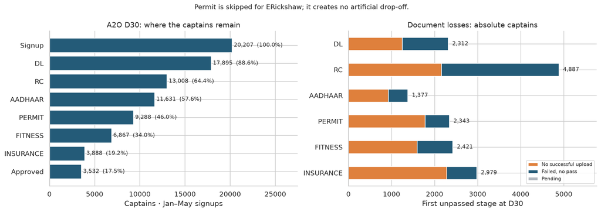

```python
# One implementation of cohorting, applicable stages, losses and primary KPIs.
core = build_onboarding_funnel(audit)
s, cohort, deadline = core.captains, core.cohort, core.deadline
event30, stage_masks, funnel = core.event30, core.stage_masks, core.funnel
docs_complete, final_lost, kpi = core.docs_complete, core.final_lost, core.kpi
N = len(cohort)
for name, frame in core.tables.items():
    show_table(name, frame)

fig, axes = plt.subplots(1,2,figsize=(14,5))
names = ['Signup'] + DOCS + ['Approved']
counts = [N] + funnel.cumulative_remaining.tolist() + [int(cohort.a2o30.sum())]
axes[0].barh(names[::-1], counts[::-1], color=BLUE)
for i,v in enumerate(counts[::-1]): axes[0].text(v+N*.01,i,f'{v:,}  ({v/N:.1%})',va='center',fontsize=9)
axes[0].set(xlim=(0,N*1.36),title='A2O D30: where the captains remain',xlabel='Captains · Jan–May signups')
loss_plot = funnel[['no_upload','failed_unresolved','pending']].copy()
loss_plot.columns = ['No successful upload','Failed, no pass','Pending']
loss_plot.plot.barh(stacked=True, ax=axes[1], color=[ORANGE,BLUE,'#B2B8BF'])
axes[1].set(title='Document losses: absolute captains',xlabel='First unpassed stage at D30',ylabel='')
axes[1].invert_yaxis()
axes[1].set_xlim(0,funnel.lost.max()*1.18)
for i,v in enumerate(funnel.lost):
    axes[1].text(v+funnel.lost.max()*.02,i,f'{v:,}',va='center',fontsize=9)
axes[1].legend(fontsize=8,loc='lower right')
fig.suptitle('Permit is skipped for ERickshaw; it creates no artificial drop-off.',fontsize=11)
fig.tight_layout(); save_figure('funnel',fig)
```

| signup_month | signups | approved_as_of_extract | minimum_age_days | raw_snapshot_a2o | eligible_d7 | a2o_d7_eligible_only | a2o_d7_complete_month | eligible_d14 | a2o_d14_eligible_only | a2o_d14_complete_month | eligible_d30 | a2o_d30_eligible_only | a2o_d30_complete_month |
| --- | --- | --- | --- | --- | --- | --- | --- | --- | --- | --- | --- | --- | --- |
| 2026-01 | 3716 | 631 | 150.092 | 0.170 | 3716 | 0.115 | 0.115 | 3716 | 0.170 | 0.170 | 3716 | 0.170 | 0.170 |
| 2026-02 | 3600 | 659 | 122.086 | 0.183 | 3600 | 0.122 | 0.122 | 3600 | 0.183 | 0.183 | 3600 | 0.183 | 0.183 |
| 2026-03 | 4188 | 751 | 91.088 | 0.179 | 4188 | 0.119 | 0.119 | 4188 | 0.179 | 0.179 | 4188 | 0.179 | 0.179 |
| 2026-04 | 4123 | 717 | 61.084 | 0.174 | 4123 | 0.118 | 0.118 | 4123 | 0.174 | 0.174 | 4123 | 0.174 | 0.174 |
| 2026-05 | 4580 | 774 | 30.090 | 0.169 | 4580 | 0.114 | 0.114 | 4580 | 0.169 | 0.169 | 4580 | 0.169 | 0.169 |
| 2026-06 | 4793 | 674 | 0.085 | 0.141 | 3711 | 0.118 | NaN | 2550 | 0.183 | NaN | 0 | NaN | NaN |

|  | days | same_signups | approved | a2o | r2a |
| --- | --- | --- | --- | --- | --- |
| 0 | 7 | 20207 | 2374 | 0.117 | 0.054 |
| 1 | 14 | 20207 | 3531 | 0.175 | 0.171 |
| 2 | 30 | 20207 | 3532 | 0.175 | 0.172 |

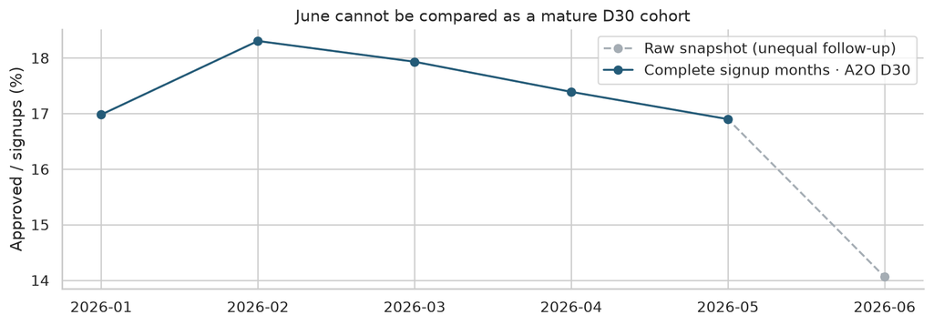

**Readout:** 20,207 mature signups produced **3,532 approvals (17.48%)** and **3,485 first orders (17.25%)** by D30. RC accounts for **4,887** lost captains, 29.3% of all A2O losses. Approval-time percentiles describe observed approvers only; they do not establish how quickly non-approvers would finish.

```python
monthly = s.groupby('signup_month').agg(signups=('signup_ts','size'),
        approved_as_of_extract=('approved_at','count'), minimum_age_days=('age_days','min'))
monthly['raw_snapshot_a2o'] = monthly.approved_as_of_extract/monthly.signups
for days in [7,14,30]:
    mature = s.age_days.ge(days)
    denom = s.loc[mature].groupby('signup_month').size()
    numer = s.loc[mature & s.approval_days.le(days)].groupby('signup_month').size()
    monthly[f'eligible_d{days}'] = denom.reindex(monthly.index,fill_value=0)
    monthly[f'a2o_d{days}_eligible_only'] = numer.reindex(monthly.index,fill_value=0)/denom
    # The complete-month trend intentionally suppresses partial June denominators.
    monthly[f'a2o_d{days}_complete_month'] = monthly[f'a2o_d{days}_eligible_only'].where(
        monthly[f'eligible_d{days}'].eq(monthly.signups))
show_table('monthly_cohort_maturity',monthly)
horizon_sensitivity = pd.DataFrame([
    {'days':d, 'same_signups':N, 'approved':int(cohort.approval_days.le(d).sum()),
     'a2o':cohort.approval_days.le(d).mean(), 'r2a':cohort.first_order_days.le(d).mean()}
    for d in [7,14,30]])
show_table('same_cohort_horizon_sensitivity',horizon_sensitivity)
fig,ax=plt.subplots(figsize=(10,3.6))
ax.plot(monthly.index,monthly.raw_snapshot_a2o*100,'o--',color='#A5ADB4',label='Raw snapshot (unequal follow-up)')
ax.plot(monthly.index,monthly.a2o_d30_complete_month*100,'o-',color=BLUE,label='Complete signup months · A2O D30')
ax.set(ylabel='Approved / signups (%)',title='June cannot be compared as a mature D30 cohort')
ax.legend(loc='best');fig.tight_layout();save_figure('cohort_maturity',fig)
display(Markdown(f'**Readout:** {N:,} mature signups produced **{cohort.a2o30.sum():,} approvals '
                 f'({cohort.a2o30.mean():.2%})** and **{cohort.r2a30.sum():,} first orders '
                 f'({cohort.r2a30.mean():.2%})** by D30. RC accounts for '
                 f'**{funnel.loc["RC","lost"]:,}** lost captains, '
                 f'{funnel.loc["RC","share_of_all_signup_losses"]:.1%} of all A2O losses. '
                 'Approval-time percentiles describe observed approvers only; they do not establish how quickly non-approvers would finish.'))
```

## A2 · Segment the leak, then price a plausible repair

Raw segment differences are diagnostic associations. Vehicle paths differ, acquisition channels may recruit different captains, and device tier may proxy for more than camera quality. Do not attribute the entire gap to a product change or reallocate acquisition spend without channel costs and a test.

The strongest directly observed mechanism is **verification failures labelled image blur / low OCR confidence / illegibility**. The largest late-stage opportunity is **no successful Insurance upload after Fitness clearance**. A missing upload does not tell us whether the captain lacked insurance, abandoned the app, or suffered an unlogged upload error; discovery and instrumentation are part of that recommendation.

|  | segment | signups | approved | active | a2o30 | not_approved_d30 | ci95_low | ci95_high | dimension |
| --- | --- | --- | --- | --- | --- | --- | --- | --- | --- |
| 0 | Bangalore | 4420 | 755 | 751 | 0.171 | 3665 | 0.160 | 0.182 | city |
| 1 | Delhi | 5215 | 1010 | 993 | 0.194 | 4205 | 0.183 | 0.205 | city |
| 2 | Hyderabad | 6193 | 1040 | 1020 | 0.168 | 5153 | 0.159 | 0.177 | city |
| 3 | Pune | 4379 | 727 | 721 | 0.166 | 3652 | 0.155 | 0.177 | city |
| 4 | Auto | 9160 | 1455 | 1435 | 0.159 | 7705 | 0.152 | 0.166 | vehicle_type |
| 5 | Cab | 7193 | 1156 | 1139 | 0.161 | 6037 | 0.152 | 0.169 | vehicle_type |
| 6 | ERickshaw | 3854 | 921 | 911 | 0.239 | 2933 | 0.226 | 0.253 | vehicle_type |
| 7 | fos_field | 5012 | 1340 | 1312 | 0.267 | 3672 | 0.255 | 0.280 | acquisition_channel |
| 8 | gc_telecalling | 1176 | 172 | 168 | 0.146 | 1004 | 0.127 | 0.168 | acquisition_channel |
| 9 | organic_app | 6758 | 1015 | 1005 | 0.150 | 5743 | 0.142 | 0.159 | acquisition_channel |
| 10 | paid_digital | 2830 | 283 | 281 | 0.100 | 2547 | 0.089 | 0.112 | acquisition_channel |
| 11 | referral | 4431 | 722 | 719 | 0.163 | 3709 | 0.152 | 0.174 | acquisition_channel |
| 12 | high | 3173 | 726 | 715 | 0.229 | 2447 | 0.215 | 0.244 | device_tier |
| 13 | low | 9290 | 1296 | 1280 | 0.140 | 7994 | 0.133 | 0.147 | device_tier |
| 14 | mid | 7744 | 1510 | 1490 | 0.195 | 6234 | 0.186 | 0.204 | device_tier |
| 15 | en | 4000 | 739 | 726 | 0.185 | 3261 | 0.173 | 0.197 | app_language |
| 16 | hi | 3995 | 708 | 700 | 0.177 | 3287 | 0.166 | 0.189 | app_language |
| 17 | kn | 4089 | 716 | 703 | 0.175 | 3373 | 0.164 | 0.187 | app_language |
| 18 | mr | 4016 | 663 | 655 | 0.165 | 3353 | 0.154 | 0.177 | app_language |
| 19 | te | 4107 | 706 | 701 | 0.172 | 3401 | 0.161 | 0.184 | app_language |
| 20 | 18-24 | 3659 | 621 | 613 | 0.170 | 3038 | 0.158 | 0.182 | age_band |
| 21 | 25-34 | 8423 | 1468 | 1448 | 0.174 | 6955 | 0.166 | 0.183 | age_band |
| 22 | 35-44 | 5697 | 1023 | 1011 | 0.180 | 4674 | 0.170 | 0.190 | age_band |
| 23 | 45+ | 2428 | 420 | 413 | 0.173 | 2008 | 0.158 | 0.189 | age_band |
| 24 | 2026-01 | 3716 | 631 | 627 | 0.170 | 3085 | 0.158 | 0.182 | signup_month |
| 25 | 2026-02 | 3600 | 659 | 648 | 0.183 | 2941 | 0.171 | 0.196 | signup_month |
| 26 | 2026-03 | 4188 | 751 | 743 | 0.179 | 3437 | 0.168 | 0.191 | signup_month |
| 27 | 2026-04 | 4123 | 717 | 699 | 0.174 | 3406 | 0.163 | 0.186 | signup_month |
| 28 | 2026-05 | 4580 | 774 | 768 | 0.169 | 3806 | 0.158 | 0.180 | signup_month |

|  | stage | device_tier | eligible | passed | conditional_pass_rate |
| --- | --- | --- | --- | --- | --- |
| 0 | DL | high | 3173 | 2767 | 0.872 |
| 1 | DL | low | 9290 | 8225 | 0.885 |
| 2 | DL | mid | 7744 | 6903 | 0.891 |
| 3 | RC | high | 2767 | 2204 | 0.797 |
| 4 | RC | low | 8225 | 5532 | 0.673 |
| 5 | RC | mid | 6903 | 5272 | 0.764 |
| 6 | AADHAAR | high | 2204 | 1963 | 0.891 |
| 7 | AADHAAR | low | 5532 | 4980 | 0.900 |
| 8 | AADHAAR | mid | 5272 | 4688 | 0.889 |
| 9 | PERMIT | high | 1596 | 1196 | 0.749 |
| 10 | PERMIT | low | 4049 | 3078 | 0.760 |
| 11 | PERMIT | mid | 3757 | 2785 | 0.741 |
| 12 | FITNESS | high | 1563 | 1271 | 0.813 |
| 13 | FITNESS | low | 4009 | 2747 | 0.685 |
| 14 | FITNESS | mid | 3716 | 2849 | 0.767 |
| 15 | INSURANCE | high | 1271 | 804 | 0.633 |
| 16 | INSURANCE | low | 2747 | 1421 | 0.517 |
| 17 | INSURANCE | mid | 2849 | 1663 | 0.584 |

| doc_type | device_tier | decided_first_attempts | failed_first_attempts | failure_rate |
| --- | --- | --- | --- | --- |
| AADHAAR | high | 2054 | 190 | 0.093 |
|  | low | 5151 | 489 | 0.095 |
|  | mid | 4878 | 488 | 0.100 |
| DL | high | 2975 | 468 | 0.157 |
|  | low | 8708 | 1185 | 0.136 |
|  | mid | 7276 | 1037 | 0.143 |
| FITNESS | high | 1335 | 180 | 0.135 |
|  | low | 3282 | 1172 | 0.357 |
|  | mid | 3077 | 634 | 0.206 |
| INSURANCE | high | 880 | 195 | 0.222 |
|  | low | 1829 | 792 | 0.433 |
|  | mid | 1877 | 506 | 0.270 |
| PERMIT | high | 1292 | 247 | 0.191 |
|  | low | 3312 | 599 | 0.181 |
|  | mid | 3020 | 548 | 0.181 |
| RC | high | 2425 | 521 | 0.215 |
|  | low | 7232 | 3171 | 0.438 |
|  | mid | 6078 | 1773 | 0.292 |

**RC image-quality signal:** first-attempt verification fails for **43.8%** of low-tier uploaders, versus **29.2%** on mid-tier and **21.5%** on high-tier devices. These are decided first attempts, so retries do not inflate the denominator.

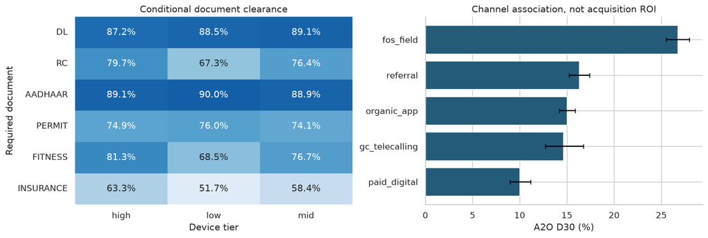

|  | doc_type | failure_reason | failure_events | unique_captains |
| --- | --- | --- | --- | --- |
| 38 | RC | image_blurred | 1865 | 1742 |
| 40 | RC | ocr_low_confidence | 1460 | 1380 |
| 39 | RC | name_mismatch | 910 | 891 |
| 36 | RC | document_expired | 755 | 744 |
| 35 | RC | details_not_legible | 689 | 672 |
| ... | ... | ... | ... | ... |
| 16 | FITNESS | duplicate_document | 130 | 130 |
| 0 | AADHAAR | details_not_legible | 123 | 123 |
| 30 | PERMIT | duplicate_document | 114 | 114 |
| 2 | AADHAAR | duplicate_document | 90 | 90 |
| 23 | INSURANCE | duplicate_document | 85 | 83 |

42 rows × 4 columns

|  | doc_type | device_tier | failure_reason | captains |
| --- | --- | --- | --- | --- |
| 0 | AADHAAR | high | details_not_legible | 5 |
| 1 | AADHAAR | high | document_expired | 14 |
| 2 | AADHAAR | high | duplicate_document | 4 |
| 3 | AADHAAR | high | image_blurred | 16 |
| 4 | AADHAAR | high | name_mismatch | 27 |
| ... | ... | ... | ... | ... |
| 121 | RC | mid | duplicate_document | 75 |
| 122 | RC | mid | image_blurred | 132 |
| 123 | RC | mid | name_mismatch | 140 |
| 124 | RC | mid | ocr_low_confidence | 120 |
| 125 | RC | mid | wrong_document_type | 103 |

126 rows × 4 columns

| doc_type | attempt_no | decided_attempts | pass_rate |
| --- | --- | --- | --- |
| AADHAAR | 1 | 12083 | 0.903 |
|  | 2 | 718 | 0.986 |
|  | 3 | 7 | 1.000 |
| DL | 1 | 18959 | 0.858 |
|  | 2 | 1668 | 0.951 |
|  | 3 | 40 | 1.000 |
| FITNESS | 1 | 7694 | 0.742 |
|  | 2 | 1307 | 0.803 |
|  | 3 | 134 | 0.813 |
| INSURANCE | 1 | 4586 | 0.674 |
|  | 2 | 939 | 0.734 |
|  | 3 | 143 | 0.741 |
| PERMIT | 1 | 7624 | 0.817 |
|  | 2 | 898 | 0.875 |
|  | 3 | 58 | 0.741 |
| RC | 1 | 15735 | 0.653 |
|  | 2 | 3418 | 0.681 |
|  | 3 | 549 | 0.745 |

| doc_type | p50 | p90 | p99 |
| --- | --- | --- | --- |
| DL | 6.400 | 16.519 | 29.616 |
| RC | 6.446 | 16.311 | 29.055 |
| AADHAAR | 6.488 | 16.633 | 30.082 |
| PERMIT | 6.374 | 16.078 | 29.032 |
| FITNESS | 6.429 | 16.151 | 28.514 |
| INSURANCE | 6.464 | 16.440 | 27.763 |

|  | low_device_eligible | low_device_in_supported_strata | strata_with_at_least_5_per_group | mid_high_minus_low_standardized_pp |
| --- | --- | --- | --- | --- |
| 0 | 8225 | 8089 | 262 | 10.181 |

```python
segment_table = summarize_segments(cohort)
show_table('segment_a2o', segment_table)

device_stage=[]
for doc in DOCS:
    for tier,g in cohort.loc[stage_masks[doc]['eligible']].groupby('device_tier'):
        passed=stage_masks[doc]['passed'].reindex(g.index).sum()
        device_stage.append({'stage':doc,'device_tier':tier,'eligible':len(g),'passed':int(passed),
                             'conditional_pass_rate':passed/len(g)})
device_stage=pd.DataFrame(device_stage)
show_table('document_device_rates',device_stage)
first_attempt_device=(event30.loc[event30.attempt_no.eq(1)&event30.event_type.ne('upload_success')]
    .merge(cohort[['device_tier']],left_on='captain_id',right_index=True)
    .assign(failed=lambda f:f.event_type.eq('verification_fail'))
    .groupby(['doc_type','device_tier']).agg(decided_first_attempts=('event_id','size'),
                                           failed_first_attempts=('failed','sum'),failure_rate=('failed','mean')))
show_table('first_attempt_failure_by_device',first_attempt_device)
display(Markdown(f'**RC image-quality signal:** first-attempt verification fails for '
    f'**{first_attempt_device.loc[("RC","low"),"failure_rate"]:.1%}** of low-tier uploaders, '
    f'versus **{first_attempt_device.loc[("RC","mid"),"failure_rate"]:.1%}** on mid-tier and '
    f'**{first_attempt_device.loc[("RC","high"),"failure_rate"]:.1%}** on high-tier devices. '
    'These are decided first attempts, so retries do not inflate the denominator.'))
fig,axes=plt.subplots(1,2,figsize=(13,4.5))
sns.heatmap(device_stage.pivot(index='stage',columns='device_tier',values='conditional_pass_rate').reindex(DOCS),
            annot=True,fmt='.1%',cmap='Blues',vmin=.45,vmax=1,ax=axes[0],cbar=False)
axes[0].set(title='Conditional document clearance',xlabel='Device tier',ylabel='Required document')
q=segment_table[segment_table.dimension.eq('acquisition_channel')].sort_values('a2o30')
axes[1].barh(q.segment,q.a2o30*100,color=BLUE)
axes[1].errorbar(q.a2o30*100,q.segment,
                 xerr=np.array([q.a2o30-q.ci95_low,q.ci95_high-q.a2o30])*100,fmt='none',color='black',capsize=3)
axes[1].set(title='Channel association, not acquisition ROI',xlabel='A2O D30 (%)')
fig.tight_layout();save_figure('segment_diagnostics',fig)

last_fail=(event30.loc[event30.event_type.eq('verification_fail')].sort_values('event_ts')
           .drop_duplicates(['captain_id','doc_type'],keep='last'))
failure_summary=event30.loc[event30.event_type.eq('verification_fail')].groupby(['doc_type','failure_reason']).agg(
    failure_events=('event_id','size'),unique_captains=('captain_id','nunique')).reset_index()
blocked_failures=[]
for doc in DOCS:
    f=last_fail.loc[last_fail.doc_type.eq(doc)].set_index('captain_id')
    b=cohort.loc[stage_masks[doc]['failed_unresolved'],['device_tier','city','vehicle_type','acquisition_channel']].join(f.failure_reason)
    b['doc_type']=doc
    blocked_failures.append(b.reset_index())
blocked_failures=pd.concat(blocked_failures,ignore_index=True)
show_table('failure_reason_events',failure_summary.sort_values('unique_captains',ascending=False))
show_table('unresolved_latest_failure_by_document_device',blocked_failures.groupby(
    ['doc_type','device_tier','failure_reason']).size().rename('captains').reset_index())
retry_table=(event30.loc[event30.event_type.ne('upload_success')]
             .assign(passed=lambda f:f.event_type.eq('verification_pass'))
             .groupby(['doc_type','attempt_no']).agg(decided_attempts=('event_id','size'),pass_rate=('passed','mean')))
show_table('retry_attempt_outcomes',retry_table)
show_table('verification_latency_hours',attempts.groupby('doc_type').verification_hours
           .quantile([.5,.9,.99]).unstack().reindex(DOCS).rename(columns={.5:'p50',.9:'p90',.99:'p99'}))
# Retry outcomes condition on reaching a retry; they are not the effect of offering another attempt.

# Standardize the RC device association over observed city × vehicle × channel × signup-month mix.
rc=cohort.loc[stage_masks['RC']['eligible']].copy()
rc['passed_rc']=stage_masks['RC']['passed'].reindex(rc.index)
rc['device_group']=np.where(rc.device_tier.eq('low'),'low','mid_high')
keys=['city','vehicle_type','acquisition_channel','signup_month']
strata=rc.groupby(keys+['device_group']).agg(n=('passed_rc','size'),rate=('passed_rc','mean')).unstack('device_group')
supported=strata.loc[(strata[('n','low')]>=5)&(strata[('n','mid_high')]>=5)]
standardized_gap=np.average(supported[('rate','mid_high')]-supported[('rate','low')],weights=supported[('n','low')])
show_table('rc_device_standardization',pd.DataFrame([{
    'low_device_eligible':int(rc.device_tier.eq('low').sum()),
    'low_device_in_supported_strata':int(supported[('n','low')].sum()),
    'strata_with_at_least_5_per_group':len(supported),
    'mid_high_minus_low_standardized_pp':100*standardized_gap}]))
```

### Opportunity model · avoid double counting and distinguish forecast from scenario

For every unpassed document, a broad benchmark is:

[ \text{extra approvals/month}=\frac{\text{D30 blocked captains}}{5} \times\text{fraction additionally clearing the stage} \times P(\text{A2O D30}\mid\text{stage passed}). ]

This is a **scenario**, not a causal estimate. Recovered captains may convert worse than historical passers and may finish outside D30. The 25% / 50% / 75% recovery values below are planning assumptions; zero impact remains possible.

For the specific Insurance intervention, recovery means an **additional successful upload**, so the downstream factor is *approval among Insurance uploaders* (it already includes verification and final review). For image-quality repair, recovery means an **additional pass**, so the downstream factor is *approval among low-tier passers of that document*. These are different transitions and are deliberately not conflated.

Use the captain's first unpassed stage for the opportunity pool. Use observable stall/failure triggers for contact volume and cost. The hindsight set of captains who never completed is **not** a deployable targeting rule.

```python
stage_opportunities=[]
for doc in DOCS:
    m=stage_masks[doc]
    downstream=cohort.loc[m['passed'],'a2o30'].mean()
    stage_opportunities.append({'stage':doc,'blocked_captains':int(m['lost'].sum()),
        'downstream_a2o_given_pass':downstream,
        'at_50pct_additional_clearance_per_month':m['lost'].sum()/MONTHS*.5*downstream})
show_table('broad_stage_scenarios',pd.DataFrame(stage_opportunities).sort_values(
    'at_50pct_additional_clearance_per_month',ascending=False))

insurance_pool=cohort.loc[stage_masks['INSURANCE']['no_upload']].copy()
insurance_landmark=cohort.pass_FITNESS+pd.Timedelta(hours=24)
insurance_trigger=cohort.pass_FITNESS.notna() & (cohort.upload_INSURANCE.isna()|
                                              cohort.upload_INSURANCE.gt(insurance_landmark))
# Use historical peers with the blocked pool's vehicle × device composition.


insurance_reference=cohort.loc[stage_masks['INSURANCE']['uploaded']]
ins_downstream,ins_min_support=transported_rate(insurance_reference,insurance_pool,['vehicle_type','device_tier'])
quality_pools=[]
for doc in ['RC','FITNESS','INSURANCE']:
    pool=blocked_failures.loc[blocked_failures.doc_type.eq(doc)&blocked_failures.device_tier.eq('low')&
                              blocked_failures.failure_reason.isin(QUALITY_REASONS)]
    reference=cohort.loc[stage_masks[doc]['passed']&cohort.device_tier.eq('low')]
    qrate,support=transported_rate(reference,pool,['vehicle_type'])
    event_targets=event30.loc[event30.doc_type.eq(doc)&event30.event_type.eq('verification_fail')&
                             event30.failure_reason.isin(QUALITY_REASONS)]
    recipients=cohort.index.isin(event_targets.captain_id)&cohort.device_tier.eq('low')
    quality_pools.append({'doc_type':doc,'blocked_latest_quality_fail':len(pool),
                          'all_observable_quality_failure_targets':int(recipients.sum()),
                          'transported_downstream_a2o':qrate,'smallest_reference_stratum':support,
                          'base_extra_approved_per_month':len(pool)/MONTHS*.5*qrate})
quality_pools=pd.DataFrame(quality_pools)
assert blocked_failures.captain_id.is_unique
assert not set(insurance_pool.index).intersection(set(blocked_failures.loc[
    blocked_failures.device_tier.eq('low')&blocked_failures.failure_reason.isin(QUALITY_REASONS),'captain_id']))
show_table('quality_repair_pools',quality_pools)

ins_base=len(insurance_pool)/MONTHS*.5*ins_downstream
quality_base=quality_pools.base_extra_approved_per_month.sum()
scenario_rows=[]
for recovery in [.25,.5,.75]:
    for transport in [.5,1.0]:
        scenario_rows.extend([
            {'intervention':'Insurance upload rescue','incremental_recovery':recovery,
             'downstream_vs_historical_peers':transport,
             'extra_approved_per_month':len(insurance_pool)/MONTHS*recovery*ins_downstream*transport},
            {'intervention':'Low-device image quality repair','incremental_recovery':recovery,
             'downstream_vs_historical_peers':transport,
             'extra_approved_per_month':quality_base*(recovery/.5)*transport}])
show_table('intervention_sensitivity',pd.DataFrame(scenario_rows))
show_table('insurance_observable_target',pd.DataFrame([{
    '24h_stall_contacts_in_5_months':int(insurance_trigger.sum()),
    'never_uploaded_pool':len(insurance_pool),
    'natural_a2o_of_24h_stalls':cohort.loc[insurance_trigger,'a2o30'].mean(),
    'transported_a2o_given_upload':ins_downstream,'min_reference_stratum':ins_min_support,
    'base_extra_approved_per_month':ins_base}]))
display(Markdown(f'**Priority by recoverable approvals:** Insurance upload rescue has a base scenario of '
    f'**{ins_base:.0f} more approvals/month**; a shared image-quality repair across RC, Fitness and Insurance '
    f'has **{quality_base:.0f}/month**. RC is the largest count leak, but the later Insurance stage has '
    'a much higher chance of turning one recovered upload into an approval. Neither scenario is a promise.'))
```

|  | stage | blocked_captains | downstream_a2o_given_pass | at_50pct_additional_clearance_per_month |
| --- | --- | --- | --- | --- |
| 5 | INSURANCE | 2979 | 0.908 | 270.623 |
| 1 | RC | 4887 | 0.272 | 132.694 |
| 4 | FITNESS | 2421 | 0.514 | 124.523 |
| 3 | PERMIT | 2343 | 0.370 | 86.663 |
| 0 | DL | 2312 | 0.197 | 45.633 |
| 2 | AADHAAR | 1377 | 0.304 | 41.816 |

|  | doc_type | blocked_latest_quality_fail | all_observable_quality_failure_targets | transported_downstream_a2o | smallest_reference_stratum | base_extra_approved_per_month |
| --- | --- | --- | --- | --- | --- | --- |
| 0 | RC | 1189 | 2371 | 0.233 | 1047 | 27.755 |
| 1 | FITNESS | 360 | 870 | 0.471 | 650 | 16.944 |
| 2 | INSURANCE | 284 | 590 | 0.912 | 348 | 25.907 |

|  | intervention | incremental_recovery | downstream_vs_historical_peers | extra_approved_per_month |
| --- | --- | --- | --- | --- |
| 0 | Insurance upload rescue | 0.250 | 0.500 | 43.845 |
| 1 | Low-device image quality repair | 0.250 | 0.500 | 17.652 |
| 2 | Insurance upload rescue | 0.250 | 1.000 | 87.690 |
| 3 | Low-device image quality repair | 0.250 | 1.000 | 35.303 |
| 4 | Insurance upload rescue | 0.500 | 0.500 | 87.690 |
| 5 | Low-device image quality repair | 0.500 | 0.500 | 35.303 |
| 6 | Insurance upload rescue | 0.500 | 1.000 | 175.379 |
| 7 | Low-device image quality repair | 0.500 | 1.000 | 70.607 |
| 8 | Insurance upload rescue | 0.750 | 0.500 | 131.534 |
| 9 | Low-device image quality repair | 0.750 | 0.500 | 52.955 |
| 10 | Insurance upload rescue | 0.750 | 1.000 | 263.069 |
| 11 | Low-device image quality repair | 0.750 | 1.000 | 105.910 |

|  | 24h_stall_contacts_in_5_months | never_uploaded_pool | natural_a2o_of_24h_stalls | transported_a2o_given_upload | min_reference_stratum | base_extra_approved_per_month |
| --- | --- | --- | --- | --- | --- | --- |
| 0 | 2695 | 2281 | 0.118 | 0.769 | 229 | 175.379 |

**Priority by recoverable approvals:** Insurance upload rescue has a base scenario of **175 more approvals/month**; a shared image-quality repair across RC, Fitness and Insurance has **71/month**. RC is the largest count leak, but the later Insurance stage has a much higher chance of turning one recovered upload into an approval. Neither scenario is a promise.

## A3 · Does `CAMP_WA_002` deserve five times the budget?

First reproduce the tempting comparison; then inspect *when* treatment was assigned. “Ever sent” vs “never sent” across all signups mixes stages, time at risk, and selection. Delivered-only or clicked-only comparisons add selection on engagement and cannot identify campaign lift.

```python
wa=nudges.loc[nudges.campaign_id.eq('CAMP_WA_002')]
assert not wa.captain_id.duplicated().any()
s['wa_ts']=wa.set_index('captain_id').sent_ts
s['ever_wa']=s.wa_ts.notna()
naive=s.groupby('ever_wa').agg(captains=('signup_ts','size'),approved=('approved_at','count'))
naive['approval_rate']=naive.approved/naive.captains
show_table('campaign_naive_all_signups',naive)
naive_diff=independent_difference_ci(s.loc[s.ever_wa,'approved_at'].notna(),
                                    s.loc[~s.ever_wa,'approved_at'].notna())
pre_wa=events.merge(wa[['captain_id','sent_ts']],on='captain_id',validate='many_to_one')
pre_wa=pre_wa.loc[pre_wa.event_ts.lt(pre_wa.sent_ts)]
passes_before_send=pre_wa.loc[pre_wa.event_type.eq('verification_pass')].groupby('captain_id').doc_type.nunique()
show_table('campaign_passes_before_send',passes_before_send.value_counts().sort_index().rename('recipients').to_frame())
show_table('campaign_hours_after_rc',((s.wa_ts-s.pass_RC).dt.total_seconds()/3600)
           .quantile([0,.1,.5,.9,.99,1]).rename('hours').to_frame())
assert s.loc[s.ever_wa,'wa_ts'].ge(s.loc[s.ever_wa,'pass_RC']).all()
stage_comparison=s.loc[s.pass_RC.notna()].groupby('ever_wa').agg(
    captains=('signup_ts','size'),approved=('approved_at','count'))
stage_comparison['approval_rate']=stage_comparison.approved/stage_comparison.captains
show_table('campaign_ever_rc_descriptive_only',stage_comparison)
```

| ever_wa | captains | approved | approval_rate |
| --- | --- | --- | --- |
| False | 16327 | 1733 | 0.106 |
| True | 8673 | 2473 | 0.285 |

| doc_type | recipients |
| --- | --- |
| 2 | 7734 |
| 3 | 892 |
| 4 | 44 |
| 5 | 3 |

|  | hours |
| --- | --- |
| 0.000 | 0.032 |
| 0.100 | 2.094 |
| 0.500 | 6.686 |
| 0.900 | 15.747 |
| 0.990 | 26.911 |
| 1.000 | 43.336 |

| ever_wa | captains | approved | approval_rate |
| --- | --- | --- | --- |
| False | 7179 | 1733 | 0.241 |
| True | 8673 | 2473 | 0.285 |

### Main design: a prespecified landmark comparison after RC clearance

| Element | Definition |
| --- | --- |
| Population | Captains with an observed RC pass and a complete 30-day window after that pass |
| Assignment window | RC pass through RC pass + 24 hours |
| Time zero for outcomes | RC pass + 24 hours, in both groups |
| Treatment | `CAMP_WA_002` **sent** within the assignment window; receipt/click is not required |
| Comparison | No send by the landmark, under the observed later messaging policy |
| Eligibility at landmark | No final approval/rejection by the landmark; report any exclusions |
| Outcome | Approval after the landmark and by RC pass + 30 days (29 days of follow-up) |
| Covariates | Signup attributes, RC calendar month, signup→DL and DL→RC timing, pre-RC failed/upload attempts, pre-RC other campaigns |
| Excluded features | Final status, snapshot docs cleared, later document events, future communications, delivery, clicks, activation |
| Main estimand | Adjusted approval-rate **association** in the overlap population of RC clearers |

Fixing the window prevents different follow-up lengths. Conditioning on survival to a landmark can still select on treatment; the 24-hour design explicitly audits early terminal decisions. Treatment can affect progress within the window, so **do not adjust for progress measured after RC clearance**. Later sends among controls remain in the control group: this compares *early send vs no early send under usual later care*, not *send vs never send*. The assignment rule and unmeasured readiness are unavailable, so causal identification is not established.

We use logistic propensity **overlap weights**, `1−p(X)` for treated and `p(X)` for controls, with a full-refit captain bootstrap for a 95% sampling interval. Weight balance, effective sample size and overlap are reported. A separate five-fold, cross-fitted doubly robust estimator compares logistic and gradient-boosted nuisance models; it targets the full eligible population and is a sensitivity analysis, not a way to select whichever estimate is most favourable.

Method references: [Hernán et al., time-zero alignment and target trials](https://pmc.ncbi.nlm.nih.gov/articles/PMC5124536/); [Li, Morgan & Zaslavsky, balancing weights](https://arxiv.org/abs/1404.1785). These methods address design/measured-confounding problems; they do not supply the missing randomization.

|  | rc_clearers | complete_followup | early_terminal_excluded | analysed | treated | controls | control_later_send_rate |
| --- | --- | --- | --- | --- | --- | --- | --- |
| 0 | 15852 | 12824 | 0 | 12824 | 6899 | 5925 | 0.021 |

| T | size | sum | mean |
| --- | --- | --- | --- |
| 0 | 5925 | 1478 | 0.249 |
| 1 | 6899 | 1998 | 0.290 |

|  | group | n | weighted_a2o | effective_sample_size | propensity_p01 | propensity_p50 | propensity_p99 |
| --- | --- | --- | --- | --- | --- | --- | --- |
| 0 | 0 | 5925 | 0.249 | 5,914.613 | 0.481 | 0.538 | 0.584 |
| 1 | 1 | 6899 | 0.291 | 6,882.717 | 0.482 | 0.540 | 0.586 |

|  | feature | smd_before | smd_after |
| --- | --- | --- | --- |
| 23 | cat__age_band_45+ | -0.041 | 0.001 |
| 22 | cat__age_band_35-44 | 0.030 | -0.000 |
| 9 | cat__acquisition_channel_organic_app | -0.028 | -0.000 |
| 18 | cat__app_language_mr | 0.026 | 0.000 |
| 16 | cat__app_language_hi | -0.025 | 0.000 |
| 34 | num__prior_CAMP_SMS_004 | -0.023 | 0.000 |
| 27 | cat__rc_month_2026-04 | -0.023 | -0.000 |
| 3 | cat__city_Pune | 0.021 | 0.000 |
| 12 | cat__device_tier_high | -0.020 | -0.000 |
| 25 | cat__rc_month_2026-02 | 0.019 | -0.000 |
| 15 | cat__app_language_en | -0.019 | -0.000 |
| 20 | cat__age_band_18-24 | -0.018 | -0.001 |
| 8 | cat__acquisition_channel_gc_telecalling | 0.016 | 0.001 |
| 33 | num__prior_CAMP_CALL_009 | -0.016 | 0.000 |
| 0 | cat__city_Bangalore | -0.016 | -0.000 |
| 10 | cat__acquisition_channel_paid_digital | 0.016 | -0.001 |
| 13 | cat__device_tier_low | 0.015 | -0.000 |
| 21 | cat__age_band_25-34 | 0.014 | -0.000 |
| 30 | num__dl_to_rc_hours | 0.013 | -0.000 |
| 5 | cat__vehicle_type_Cab | 0.012 | -0.000 |

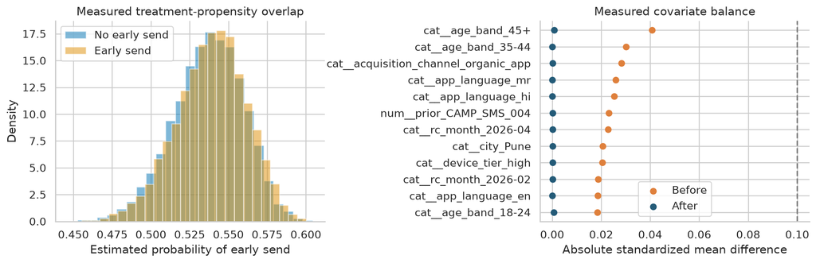

```python
rc_base=s.loc[s.pass_RC.notna()].copy()
pre_rc=events.merge(rc_base[['pass_RC']],left_on='captain_id',right_index=True)
pre_rc=pre_rc.loc[pre_rc.event_ts.le(pre_rc.pass_RC)]
rc_base['rc_month']=rc_base.pass_RC.dt.strftime('%Y-%m')
rc_base['signup_to_dl_hours']=(rc_base.pass_DL-rc_base.signup_ts).dt.total_seconds()/3600
rc_base['dl_to_rc_hours']=(rc_base.pass_RC-rc_base.pass_DL).dt.total_seconds()/3600
rc_base['pre_rc_failures']=pre_rc.loc[pre_rc.event_type.eq('verification_fail')].groupby('captain_id').size().reindex(rc_base.index,fill_value=0)
rc_base['pre_rc_uploads']=pre_rc.loc[pre_rc.event_type.eq('upload_success')].groupby('captain_id').size().reindex(rc_base.index,fill_value=0)
prior_nudges=nudges.merge(rc_base[['pass_RC']],left_on='captain_id',right_index=True)
prior_nudges=prior_nudges.loc[prior_nudges.sent_ts.lt(prior_nudges.pass_RC)]
assert not prior_nudges.campaign_id.eq('CAMP_WA_002').any()
OTHER_CAMPAIGNS=sorted(prior_nudges.campaign_id.unique())
prior_cols=[]
for campaign in OTHER_CAMPAIGNS:
    col='prior_'+campaign
    rc_base[col]=rc_base.index.isin(prior_nudges.loc[prior_nudges.campaign_id.eq(campaign),'captain_id']).astype(int)
    prior_cols.append(col)
CAT=['city','vehicle_type','acquisition_channel','device_tier','app_language','age_band','rc_month']
NUM=['signup_to_dl_hours','dl_to_rc_hours','pre_rc_failures','pre_rc_uploads']+prior_cols
FEATURES=CAT+NUM
assert not rc_base[FEATURES].isna().any().any()

def campaign_cohort(hours=24, horizon_days=30):
    b=rc_base.loc[rc_base.pass_RC.add(pd.Timedelta(days=horizon_days)).le(CUTOFF)].copy()
    mature_n=len(b)
    b['landmark']=b.pass_RC+pd.Timedelta(hours=hours)
    early=b.decision_ts.le(b.landmark)
    excluded=int(early.sum())
    b=b.loc[~early].copy()
    b['T']=b.wa_ts.le(b.landmark).astype(int)
    b['Y']=(b.approved_at.gt(b.landmark)&b.approved_at.le(b.pass_RC+pd.Timedelta(days=horizon_days))).astype(int)
    b['later_send']=(b.wa_ts.gt(b.landmark)&b.wa_ts.le(b.pass_RC+pd.Timedelta(days=horizon_days)))
    return b, {'rc_clearers':len(rc_base),'complete_followup':mature_n,
               'early_terminal_excluded':excluded,'analysed':len(b),
               'treated':int(b['T'].sum()),'controls':int(b['T'].eq(0).sum()),
               'control_later_send_rate':b.loc[b['T'].eq(0),'later_send'].mean()}

def make_adjustment_model(kind='logistic'):
    prep=ColumnTransformer([('cat',OneHotEncoder(handle_unknown='ignore',sparse_output=False),CAT),
                            ('num',StandardScaler(),NUM)])
    if kind=='logistic':
        model=LogisticRegression(C=10,max_iter=1500,solver='lbfgs',random_state=SEED)
    else:
        model=HistGradientBoostingClassifier(max_iter=130,max_leaf_nodes=7,min_samples_leaf=80,
                   learning_rate=.05,l2_regularization=5,early_stopping=False,random_state=SEED)
    return make_pipeline(prep,model)

campaign, attrition=campaign_cohort()
assert campaign.index.is_unique
show_table('campaign_design_attrition',pd.DataFrame([attrition]))
show_table('campaign_landmark_raw_rates',campaign.groupby('T').Y.agg(['size','sum','mean']))
X=campaign[FEATURES];T=campaign['T'].to_numpy();Y=campaign['Y'].to_numpy()
with threadpool_limits(limits=2):
    propensity=make_adjustment_model().fit(X,T)
p=propensity.predict_proba(X)[:,1]
weights=np.where(T==1,1-p,p)

def weighted_difference(y,t,w):
    return np.average(y[t==1],weights=w[t==1])-np.average(y[t==0],weights=w[t==0])

ow_estimate=weighted_difference(Y,T,weights)
weighted_rates=[np.average(Y[T==g],weights=weights[T==g]) for g in [0,1]]
diagnostics=[]
for g in [0,1]:
    wg=weights[T==g]
    diagnostics.append({'group':g,'n':int((T==g).sum()),'weighted_a2o':weighted_rates[g],
                         'effective_sample_size':wg.sum()**2/(wg@wg),
                         'propensity_p01':np.quantile(p[T==g],.01),
                         'propensity_p50':np.median(p[T==g]),'propensity_p99':np.quantile(p[T==g],.99)})
show_table('campaign_overlap_diagnostics',pd.DataFrame(diagnostics))

design=propensity.named_steps['columntransformer'].transform(X)
feature_names=propensity.named_steps['columntransformer'].get_feature_names_out()
scale=np.sqrt((design[T==1].var(axis=0)+design[T==0].var(axis=0))/2)
scale=np.where(scale>1e-10,scale,1)
balance=pd.DataFrame({'feature':feature_names,
    'smd_before':(design[T==1].mean(axis=0)-design[T==0].mean(axis=0))/scale,
    'smd_after':(np.average(design[T==1],axis=0,weights=weights[T==1])-
                 np.average(design[T==0],axis=0,weights=weights[T==0]))/scale})
show_table('campaign_covariate_balance',balance.sort_values('smd_before',key=abs,ascending=False).head(20))
tables['campaign_covariate_balance_full']=balance
assert np.isfinite(weights).all() and weights.min()>0
assert balance.smd_after.abs().max()<.1, 'Residual measured imbalance needs review.'

fig,axes=plt.subplots(1,2,figsize=(12,4))
for g,label in [(0,'No early send'),(1,'Early send')]:
    axes[0].hist(p[T==g],bins=25,alpha=.5,density=True,label=label)
axes[0].set(title='Measured treatment-propensity overlap',xlabel='Estimated probability of early send',ylabel='Density')
axes[0].legend()
top=balance.assign(abs_before=balance.smd_before.abs()).nlargest(12,'abs_before').iloc[::-1]
axes[1].scatter(top.smd_before.abs(),top.feature,label='Before',color=ORANGE)
axes[1].scatter(top.smd_after.abs(),top.feature,label='After',color=BLUE)
axes[1].axvline(.1,color='grey',linestyle='--')
axes[1].set(title='Measured covariate balance',xlabel='Absolute standardized mean difference')
axes[1].legend();fig.tight_layout();save_figure('campaign_balance',fig)
```

```python
# Captain-level ordinary bootstrap; refit the propensity model in EVERY resample.
# No repeated rows per captain in the analysis. The interval covers sampling/model fit,
# not unmeasured confounding, spillovers, or a change in audience at 5x spending.
BOOTSTRAPS=300
rng=np.random.default_rng(SEED)
boot=[]
with threadpool_limits(limits=2):
    for b in range(BOOTSTRAPS):
        idx=rng.integers(0,len(campaign),len(campaign))
        xb=X.iloc[idx];tb=T[idx];yb=Y[idx]
        fit=make_adjustment_model().fit(xb,tb)
        pb=fit.predict_proba(xb)[:,1]
        wb=np.where(tb==1,1-pb,pb)
        boot.append(weighted_difference(yb,tb,wb))
ow_ci=np.quantile(boot,[.025,.975])
landmark_diff=independent_difference_ci(Y[T==1],Y[T==0])
effect_rows=[
    {'design':'All signups, ever sent (biased descriptive comparison)',
     'estimate':naive_diff[0],'ci_low':naive_diff[1],'ci_high':naive_diff[2],'population':'All signups'},
    {'design':'RC + 24h landmark, unadjusted','estimate':landmark_diff[0],
     'ci_low':landmark_diff[1],'ci_high':landmark_diff[2],'population':'Eligible RC clearers'},
    {'design':'RC + 24h landmark, overlap weighted','estimate':ow_estimate,
     'ci_low':ow_ci[0],'ci_high':ow_ci[1],'population':'Overlap population'}]
show_table('campaign_primary_estimates',pd.DataFrame(effect_rows))
display(Markdown(f'**Deck number:** early `CAMP_WA_002` sending is associated with '
    f'**{100*ow_estimate:+.2f} percentage points** in approval among comparable RC clearers '
    f'(95% captain-bootstrap interval **{100*ow_ci[0]:+.2f} to {100*ow_ci[1]:+.2f} pp**). '
    'This is an adjusted association, not proven incremental lift.'))
```

|  | design | estimate | ci_low | ci_high | population |
| --- | --- | --- | --- | --- | --- |
| 0 | All signups, ever sent (biased descriptive com... | 0.179 | 0.168 | 0.190 | All signups |
| 1 | RC + 24h landmark, unadjusted | 0.040 | 0.025 | 0.055 | Eligible RC clearers |
| 2 | RC + 24h landmark, overlap weighted | 0.042 | 0.027 | 0.058 | Overlap population |

**Deck number:** early `CAMP_WA_002` sending is associated with **+4.17 percentage points** in approval among comparable RC clearers (95% captain-bootstrap interval **+2.68 to +5.82 pp**). This is an adjusted association, not proven incremental lift.

|  | design | estimate | ci_low | ci_high | population | propensity_auc_oof | outcome_auc_oof | outcome_brier_oof | propensity_clipped_fraction |
| --- | --- | --- | --- | --- | --- | --- | --- | --- | --- |
| 0 | Cross-fitted AIPW · logistic | 0.042 | 0.027 | 0.058 | All eligible RC clearers | 0.503 | 0.619 | 0.191 | 0.000 |
| 1 | Cross-fitted AIPW · boosting | 0.042 | 0.027 | 0.057 | All eligible RC clearers | 0.504 | 0.612 | 0.192 | 0.000 |

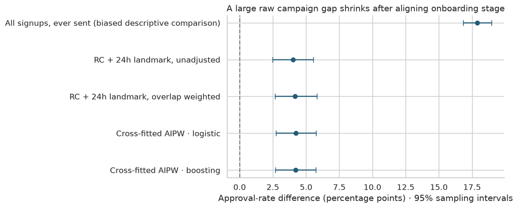

|  | landmark_hours | horizon_after_rc_days | rc_clearers | complete_followup | early_terminal_excluded | analysed | treated | controls | control_later_send_rate | overlap_association_pp |
| --- | --- | --- | --- | --- | --- | --- | --- | --- | --- | --- |
| 0 | 12 | 30 | 15852 | 12824 | 0 | 12824 | 5593 | 7231 | 0.198 | 3.566 |
| 1 | 24 | 14 | 15852 | 14432 | 0 | 14432 | 7786 | 6646 | 0.021 | 4.195 |
| 2 | 24 | 30 | 15852 | 12824 | 0 | 12824 | 6899 | 5925 | 0.021 | 4.169 |
| 3 | 48 | 30 | 15852 | 12824 | 49 | 12775 | 6996 | 5779 | 0.000 | 4.160 |

|  | rc_month | captains | weighted_difference_pp |
| --- | --- | --- | --- |
| 0 | 2026-01 | 2178 | 7.289 |
| 1 | 2026-02 | 2283 | 1.737 |
| 2 | 2026-03 | 2746 | 4.463 |
| 3 | 2026-04 | 2642 | 3.202 |
| 4 | 2026-05 | 2975 | 4.337 |

```python
# Five-fold cross fitting: no row is used to train its own nuisance predictions.
# Outcome models are trained separately in each treatment arm using baseline features.
def crossfit_aipw(frame,kind):
    xx=frame[FEATURES];tt=frame['T'].to_numpy();yy=frame['Y'].to_numpy()
    ep=np.zeros(len(frame));mu0=np.zeros(len(frame));mu1=np.zeros(len(frame))
    cv=StratifiedKFold(n_splits=5,shuffle=True,random_state=SEED)
    with threadpool_limits(limits=2):
        for train,test in cv.split(xx,tt*2+yy):
            treatment_model=make_adjustment_model(kind).fit(xx.iloc[train],tt[train])
            ep[test]=treatment_model.predict_proba(xx.iloc[test])[:,1]
            for g,target in [(0,mu0),(1,mu1)]:
                idx=train[tt[train]==g]
                outcome_model=make_adjustment_model(kind).fit(xx.iloc[idx],yy[idx])
                target[test]=outcome_model.predict_proba(xx.iloc[test])[:,1]
    clipped=np.clip(ep,.03,.97)
    score=mu1-mu0+tt*(yy-mu1)/clipped-(1-tt)*(yy-mu0)/(1-clipped)
    estimate=score.mean();se=score.std(ddof=1)/np.sqrt(len(score))
    factual=np.where(tt==1,mu1,mu0)
    return {'design':f'Cross-fitted AIPW · {kind}', 'estimate':estimate,
        'ci_low':estimate-1.96*se,'ci_high':estimate+1.96*se,'population':'All eligible RC clearers',
        'propensity_auc_oof':roc_auc_score(tt,ep),'outcome_auc_oof':roc_auc_score(yy,factual),
        'outcome_brier_oof':brier_score_loss(yy,factual),'propensity_clipped_fraction':np.mean(ep!=clipped)}

ml_results=pd.DataFrame([crossfit_aipw(campaign,k) for k in ['logistic','boosting']])
show_table('campaign_crossfit_model_sensitivity',ml_results)
all_effects=pd.concat([pd.DataFrame(effect_rows),ml_results],ignore_index=True)
fig,ax=plt.subplots(figsize=(10,4.3))
plot=all_effects.iloc[::-1]
ax.errorbar(plot.estimate*100,plot.design,
    xerr=np.array([plot.estimate-plot.ci_low,plot.ci_high-plot.estimate])*100,
    fmt='o',color=BLUE,capsize=4)
ax.axvline(0,color='grey',linestyle='--')
ax.set(title='A large raw campaign gap shrinks after aligning onboarding stage',
       xlabel='Approval-rate difference (percentage points) · 95% sampling intervals')
fig.tight_layout();save_figure('campaign_estimates',fig)

design_sensitivity=[]
for h,days in [(12,30),(24,14),(24,30),(48,30)]:
    b,info=campaign_cohort(h,days)
    with threadpool_limits(limits=2):
        fit=make_adjustment_model().fit(b[FEATURES],b['T'])
    pp=fit.predict_proba(b[FEATURES])[:,1]
    ww=np.where(b['T'].to_numpy()==1,1-pp,pp)
    design_sensitivity.append({'landmark_hours':h,'horizon_after_rc_days':days,**info,
        'overlap_association_pp':100*weighted_difference(b['Y'].to_numpy(),b['T'].to_numpy(),ww)})
show_table('campaign_timing_sensitivity',pd.DataFrame(design_sensitivity))
month_effects=[]
for month,b in campaign.groupby('rc_month'):
    ix=campaign.index.get_indexer(b.index)
    month_effects.append({'rc_month':month,'captains':len(b),
                          'weighted_difference_pp':100*weighted_difference(Y[ix],T[ix],weights[ix])})
show_table('campaign_month_stability',pd.DataFrame(month_effects))
```

### Confidence, scaling, and the experiment that would settle it

Confidence is **high in the descriptive counts**, **moderate in the measured-adjusted association**, and **low in a causal or 5× forecast**. The cohort and timing sensitivities change populations/strategies; do not treat them as interchangeable estimates of one effect. Good balance only checks the covariates we possess. Motivation, insurance readiness, agent discretion, campaign eligibility and the actual assignment mechanism are not logged. The bootstrap also assumes independent captains; shared operational shocks are outside its interval.

An omitted-factor illustration below asks how strong a selection mechanism could erase the association. It is not a statistical test: in a simple additive setup, an unmeasured readiness factor's prevalence difference multiplied by its approval-rate effect produces the bias. This makes the identification risk visible even if the sampling interval excludes zero.

Do not approve a blanket 5× budget increase. First distinguish five times the recipients from five times the touches: this dataset logs one WA002 send per recipient and contains no evidence on repeat-message dose response. Test randomized **early send vs a suppressed WA002 holdout** at RC clearance, with the same eligibility and other communication policy in both arms. Randomize captains, stratify by city/vehicle/device, analyse assignment regardless of delivery, and prevent cross-arm reassignment. Measure A2O within 30 days of randomization, R2A by D30, cost per incremental approval, opt-outs/complaints and verification/fraud quality. Report all assigned captains after full follow-up; do not stop when results first look significant.

```python
unmeasured=pd.DataFrame({'unmeasured_readiness_approval_gap':[.10,.20,.30,.40]})
unmeasured['prevalence_gap_needed_to_explain_association']=ow_estimate/unmeasured.unmeasured_readiness_approval_gap
show_table('campaign_unmeasured_confounding_illustration',unmeasured)

eligible_monthly=len(campaign)/MONTHS
ever_in_window=(campaign.wa_ts.le(campaign.pass_RC+HORIZON)).sum()
untouched=len(campaign)-ever_in_window
scale_ceiling=len(campaign)/ever_in_window
additional_recipients_monthly=untouched/MONTHS
conditional_campaign_gain=additional_recipients_monthly*ow_estimate
scale_table=pd.DataFrame([{'eligible_rc_captains_per_month':eligible_monthly,
    'already_sent_per_month':ever_in_window/MONTHS,
    'not_sent_per_month':additional_recipients_monthly,
    'max_unique_reach_multiple_at_same_flow':scale_ceiling,
    'extra_approved_if_association_were_causal_and_transportable':conditional_campaign_gain,
    'proven_incremental_approvals':np.nan}])
show_table('campaign_scaling_capacity',scale_table)

def binary_trial_n(p0,delta,power=.8,alpha=.05):
    # Normal approximation for equal allocation, two-sided test; no attrition allowance.
    p1=p0+delta;pbar=(p0+p1)/2
    n=(norm.ppf(1-alpha/2)*np.sqrt(2*pbar*(1-pbar))+
        norm.ppf(power)*np.sqrt(p0*(1-p0)+p1*(1-p1)))**2/delta**2
    return int(np.ceil(n))
p0=weighted_rates[0]
trial_rows=[]
for delta in [.02,.04,.06]:
    arm=binary_trial_n(p0,delta)
    trial_rows.append({'minimum_detectable_lift_pp':delta*100,'control_rate_assumption':p0,
                      'per_arm':arm,'total':arm*2,'accrual_months_at_historical_rc_flow':arm*2/eligible_monthly,
                      'plus_followup_days':30})
trial_size=pd.DataFrame(trial_rows)
show_table('campaign_randomized_trial_size',trial_size)
trial_n=int(trial_size.loc[trial_size.minimum_detectable_lift_pp.eq(4),'total'].iloc[0])
display(Markdown(f'At the historical flow, WA002 already reaches **{ever_in_window/len(campaign):.1%}** '
    f'of eligible RC clearers. Unique reach can grow only **{scale_ceiling:.2f}×**, not 5×, without changing '
    f'the audience or signup flow. The uncontacted pool is about **{additional_recipients_monthly:.0f}/month**. '
    f'Applying the observed association to all of them would imply **{conditional_campaign_gain:.0f} extra approvals/month**, '
    f'**only if causal and transportable**. A 4 pp randomized test needs about **{trial_n:,} captains total**, '
    'plus full outcome follow-up.'))
```

|  | unmeasured_readiness_approval_gap | prevalence_gap_needed_to_explain_association |
| --- | --- | --- |
| 0 | 0.100 | 0.417 |
| 1 | 0.200 | 0.208 |
| 2 | 0.300 | 0.139 |
| 3 | 0.400 | 0.104 |

|  | eligible_rc_captains_per_month | already_sent_per_month | not_sent_per_month | max_unique_reach_multiple_at_same_flow | extra_approved_if_association_were_causal_and_transportable | proven_incremental_approvals |
| --- | --- | --- | --- | --- | --- | --- |
| 0 | 2,564.800 | 1,404.600 | 1,160.200 | 1.826 | 48.374 | NaN |

|  | minimum_detectable_lift_pp | control_rate_assumption | per_arm | total | accrual_months_at_historical_rc_flow | plus_followup_days |
| --- | --- | --- | --- | --- | --- | --- |
| 0 | 2.000 | 0.249 | 7527 | 15054 | 5.869 | 30 |
| 1 | 4.000 | 0.249 | 1928 | 3856 | 1.503 | 30 |
| 2 | 6.000 | 0.249 | 876 | 1752 | 0.683 | 30 |

At the historical flow, WA002 already reaches **54.8%** of eligible RC clearers. Unique reach can grow only **1.83×**, not 5×, without changing the audience or signup flow. The uncontacted pool is about **1160/month**. Applying the observed association to all of them would imply **48 extra approvals/month**, **only if causal and transportable**. A 4 pp randomized test needs about **3,856 captains total**, plus full outcome follow-up.

## A4 · Three ranked recommendations

Rank by credible mechanism, recoverable approval volume, and effort. Monetary values below are **illustrative planning inputs, not prices present in the data**. Replace them with Finance/vendor quotes. Fixed engineering, tooling, overhead and acquisition costs are additional; no lifetime value or profitability is inferred from order counts.

The two operational opportunity pools are disjoint at their first unpassed stage. The campaign acts across those journeys, so its scenario **must not be added** to product-fix scenarios. Even the two disjoint pools can interact when deployed together; validate the combined impact experimentally.

```python
# Editable cost assumptions; INR. There are no actual spend data in the supplied files.
COST={'insurance_contact_inr':20.,'quality_assistance_per_captain_doc_inr':15.,'wa_send_inr':1.}
ins_monthly_cost=insurance_trigger.sum()/MONTHS*COST['insurance_contact_inr']
quality_targets=quality_pools.all_observable_quality_failure_targets.sum()/MONTHS
quality_monthly_cost=quality_targets*COST['quality_assistance_per_captain_doc_inr']
wa_monthly_cost=additional_recipients_monthly*COST['wa_send_inr']
recommendations=pd.DataFrame([
    {'rank':1,'action':'Insurance upload rescue after a 24-hour stall',
     'expected_impact_base_scenario_per_month':ins_base,
     'working':f'{len(insurance_pool):,} / 5 × 50% additional uploads × {ins_downstream:.3f} downstream approval',
     'illustrative_variable_cost_inr_per_month':ins_monthly_cost,
     'illustrative_cost_per_extra_approval_inr':ins_monthly_cost/ins_base,
     'owner':'Onboarding product + city operations',
     'what_to_do':'After Fitness passes, deep-link the remaining upload; offer a scheduled support callback after 24h without upload. Interview a sample about document availability.',
     'risks':'Some captains lack valid insurance; never waive verification. Reminder fatigue, agent cost, and worse conversion among recovered users.',
     'measure':'Randomized holdout among 24h stalls; incremental Insurance uploads and A2O within signup D30, R2A D30, cost/incremental approval, invalid-document rate and complaints.'},
    {'rank':2,'action':'Repair image-quality failures on low-tier devices',
     'expected_impact_base_scenario_per_month':quality_base,
     'working':'Sum over RC/Fitness/Insurance: latest unresolved quality failures / 5 × 50% additional passes × vehicle-standardized low-device downstream A2O',
     'illustrative_variable_cost_inr_per_month':quality_monthly_cost,
     'illustrative_cost_per_extra_approval_inr':quality_monthly_cost/quality_base,
     'owner':'Document product + verification operations',
     'what_to_do':'Pilot guided capture, legibility/blur feedback, resumable upload and assisted recapture. Start with RC; extend the same component to Fitness and Insurance.',
     'risks':'No image pixels or upload-failure logs are supplied; diagnose first. False rejections, latency on low-tier devices, manual review load, privacy and fraud escape.',
     'measure':'Randomize low-tier captains before the first RC upload; subgroup first-pass rates, failed attempts, A2O/R2A D30, p95 latency, review minutes and audited false accepts.'},
    {'rank':3,'action':'Hold the 5× campaign request; run an RC-stage randomized test',
     'expected_impact_base_scenario_per_month':np.nan,
     'working':f'No causal forecast booked. Conditional full-reach scenario: {additional_recipients_monthly:.1f} new recipients/month × {ow_estimate:.4f} = {conditional_campaign_gain:.1f} approvals/month.',
     'illustrative_variable_cost_inr_per_month':wa_monthly_cost,
     'illustrative_cost_per_extra_approval_inr':np.nan,
     'owner':'Growth + analytics',
     'what_to_do':f'Randomize about {trial_n:,} RC clearers 1:1 to early WA002 or holdout, suppress crossovers, reconcile click/delivery telemetry; then scale only if incremental economics pass.',
     'risks':'Unmeasured targeting, overlap with other interventions, spam/opt-outs and unknown repeated-touch returns; suppressing current sends has opportunity cost.',
     'measure':'Pre-register assignment-based A2O at 30 days after RC randomization, R2A D30, delivery and complaints, actual spend and cost per incremental approval.'}
])
show_table('ranked_recommendations',recommendations)
for rec in recommendations.to_dict('records'):
    impact=(f"{rec['expected_impact_base_scenario_per_month']:.0f} additional approvals/month in the base scenario"
            if pd.notna(rec['expected_impact_base_scenario_per_month']) else 'No causal forecast booked')
    cost_note=' This prices full additional campaign reach, not the experiment.' if rec['rank']==3 else ''
    display(Markdown(f"### {rec['rank']}. {rec['action']}\n\n"
        f"**Owner:** {rec['owner']}. **Action:** {rec['what_to_do']}\n\n"
        f"**Impact:** {impact}. **Working:** {rec['working']}.\n\n"
        f"**Illustrative variable cost:** INR {rec['illustrative_variable_cost_inr_per_month']:,.0f}/month, "
        f"excluding fixed costs.{cost_note}\n\n"
        f"**Cost or risk:** {rec['risks']}\n\n**Success measures:** {rec['measure']}"))
show_table('illustrative_cost_inputs',pd.Series(COST,name='INR').to_frame())
display(Markdown(
    f'**Decision brief.** A2O D30 is **{cohort.a2o30.mean():.1%}**: {cohort.a2o30.sum():,} of {N:,} mature '
    f'signups approved. Prioritize the **Insurance upload handoff** (~{ins_base:.0f} approvals/month in the 50% '
    f'recovery scenario), then **low-device document image quality** (~{quality_base:.0f}/month). '
    f'These scenarios halve if recovered captains convert at half the peer rate. '
    f'WA002 shows **{ow_estimate*100:+.1f} pp adjusted association** '
    f'(95% sampling interval {ow_ci[0]*100:+.1f} to {ow_ci[1]*100:+.1f}); '
    '**run the randomized test before approving 5× spend**. No incremental campaign approvals are booked as proven.'))
```

|  | rank | action | expected_impact_base_scenario_per_month | working | illustrative_variable_cost_inr_per_month | illustrative_cost_per_extra_approval_inr | owner | what_to_do | risks | measure |
| --- | --- | --- | --- | --- | --- | --- | --- | --- | --- | --- |
| 0 | 1 | Insurance upload rescue after a 24-hour stall | 175.379 | 2,281 / 5 × 50% additional uploads × 0.769 dow... | 10,780.000 | 61.467 | Onboarding product + city operations | After Fitness passes, deep-link the remaining ... | Some captains lack valid insurance; never waiv... | Randomized holdout among 24h stalls; increment... |
| 1 | 2 | Repair image-quality failures on low-tier devices | 70.607 | Sum over RC/Fitness/Insurance: latest unresolv... | 11,493.000 | 162.775 | Document product + verification operations | Pilot guided capture, legibility/blur feedback... | No image pixels or upload-failure logs are sup... | Randomize low-tier captains before the first R... |
| 2 | 3 | Hold the 5× campaign request; run an RC-stage ... | NaN | No causal forecast booked. Conditional full-re... | 1,160.200 | NaN | Growth + analytics | Randomize about 3,856 RC clearers 1:1 to early... | Unmeasured targeting, overlap with other inter... | Pre-register assignment-based A2O at 30 days a... |

1. Insurance upload rescue after a 24-hour stall

**Owner:** Onboarding product + city operations. **Action:** After Fitness passes, deep-link the remaining upload; offer a scheduled support callback after 24h without upload. Interview a sample about document availability.

**Impact:** 175 additional approvals/month in the base scenario. **Working:** 2,281 / 5 × 50% additional uploads × 0.769 downstream approval.

**Illustrative variable cost:** INR 10,780/month, excluding fixed costs.

**Cost or risk:** Some captains lack valid insurance; never waive verification. Reminder fatigue, agent cost, and worse conversion among recovered users.

**Success measures:** Randomized holdout among 24h stalls; incremental Insurance uploads and A2O within signup D30, R2A D30, cost/incremental approval, invalid-document rate and complaints.

2. Repair image-quality failures on low-tier devices

**Owner:** Document product + verification operations. **Action:** Pilot guided capture, legibility/blur feedback, resumable upload and assisted recapture. Start with RC; extend the same component to Fitness and Insurance.

**Impact:** 71 additional approvals/month in the base scenario. **Working:** Sum over RC/Fitness/Insurance: latest unresolved quality failures / 5 × 50% additional passes × vehicle-standardized low-device downstream A2O.

**Illustrative variable cost:** INR 11,493/month, excluding fixed costs.

**Cost or risk:** No image pixels or upload-failure logs are supplied; diagnose first. False rejections, latency on low-tier devices, manual review load, privacy and fraud escape.

**Success measures:** Randomize low-tier captains before the first RC upload; subgroup first-pass rates, failed attempts, A2O/R2A D30, p95 latency, review minutes and audited false accepts.

3. Hold the 5× campaign request; run an RC-stage randomized test

**Owner:** Growth + analytics. **Action:** Randomize about 3,856 RC clearers 1:1 to early WA002 or holdout, suppress crossovers, reconcile click/delivery telemetry; then scale only if incremental economics pass.

**Impact:** No causal forecast booked. **Working:** No causal forecast booked. Conditional full-reach scenario: 1160.2 new recipients/month × 0.0417 = 48.4 approvals/month..

**Illustrative variable cost:** INR 1,160/month, excluding fixed costs. This prices full additional campaign reach, not the experiment.

**Cost or risk:** Unmeasured targeting, overlap with other interventions, spam/opt-outs and unknown repeated-touch returns; suppressing current sends has opportunity cost.

**Success measures:** Pre-register assignment-based A2O at 30 days after RC randomization, R2A D30, delivery and complaints, actual spend and cost per incremental approval.

|  | INR |
| --- | --- |
| insurance_contact_inr | 20.000 |
| quality_assistance_per_captain_doc_inr | 15.000 |
| wa_send_inr | 1.000 |

**Decision brief.** A2O D30 is **17.5%**: 3,532 of 20,207 mature signups approved. Prioritize the **Insurance upload handoff** (~175 approvals/month in the 50% recovery scenario), then **low-device document image quality** (~71/month). These scenarios halve if recovered captains convert at half the peer rate. WA002 shows **+4.2 pp adjusted association** (95% sampling interval +2.7 to +5.8); **run the randomized test before approving 5× spend**. No incremental campaign approvals are booked as proven.

### Measurement and ownership details

- **Monday:** instrument upload start/error/abandonment and the remaining-document view; inspect a sample of missing Insurance uploads and low-device failed RC captures; give Ops a timestamp-based stall queue. Do not infer unlogged upload errors from the absence of a successful upload.
- **Experiments:** persist eligibility, random assignment, campaign version and suppression logs. Use one assignment per captain. Use a factorial design or mutually exclusive buckets if testing campaign and product changes simultaneously. Analyse at the assignment unit; keep all eligible assigned captains in the denominator.
- **Decision gate:** require positive incremental A2O with a useful interval, acceptable R2A/fraud/complaint guardrails, and cost per incremental approval below a Finance-approved value. A high first-pass rate alone is insufficient if quality falls or approvals do not rise.
- **Data contract:** reconcile the June summary counts with event time; distinguish pending from terminal abandonment; fix click/delivery inconsistency; define D7/D30 aggregation clocks and investigate `orders_d7 > orders_d30`. Add campaign assignment reasons and actual communication/agent/acquisition costs.
- **Limits:** observed approvals occur quickly, but unresolved captains' eventual outcomes are unknown. Document recovery, peer-rate transport, constant monthly flow and linear scaling are assumptions. No city-specific acquisition ROI, lifetime value, or airport conclusion can be supported by this Part A analysis.

```python
# Reproducibility and final analytical checks. No raw files are modified.
assert cohort.r2a30.sum()<=cohort.a2o30.sum()
assert (cohort.loc[cohort.r2a30,'first_order_ts']>=cohort.loc[cohort.r2a30,'approved_at']).all()
assert len(set(insurance_pool.index))==len(insurance_pool)
assert len(boot)==BOOTSTRAPS and np.isfinite(boot).all()
assert all_effects[['estimate','ci_low','ci_high']].notna().all().all()
assert attrition['early_terminal_excluded']==0, 'Primary landmark eligibility needs renewed bias review.'
assert all((ROOT/'Data'/f'{n}.csv').exists() for n in FILES)
for item in manifest:
    assert hashlib.sha256((ROOT/'Data'/item['file']).read_bytes()).hexdigest()==item['sha256']
for name,frame in tables.items():
    frame.to_csv(OUT/f'{name}.csv',index=True)

summary={
 'cohort_signups':N,'cohort_approved':int(cohort.a2o30.sum()),'cohort_active':int(cohort.r2a30.sum()),
 'a2o30':float(cohort.a2o30.mean()),'r2a30':float(cohort.r2a30.mean()),
 'rc_lost':int(funnel.loc['RC','lost']),'insurance_no_upload':len(insurance_pool),
 'insurance_trigger_count':int(insurance_trigger.sum()),'insurance_downstream':ins_downstream,
 'insurance_monthly_gain':ins_base,'quality_monthly_gain':quality_base,
 'insurance_monthly_cost':float(ins_monthly_cost),'quality_monthly_cost':float(quality_monthly_cost),
 'campaign_naive_pp':float(naive_diff[0]*100),'campaign_association_pp':float(ow_estimate*100),
 'campaign_ci_pp':[float(v*100) for v in ow_ci],
 'campaign_weighted_rates':weighted_rates,'campaign_n':len(campaign),
 'campaign_coverage':float(ever_in_window/len(campaign)),
 'campaign_reach_ceiling':float(scale_ceiling),'campaign_extra_recipients_monthly':float(additional_recipients_monthly),
 'campaign_conditional_monthly_gain':float(conditional_campaign_gain),'trial_total':trial_n,
 'trial_accrual_months':float(trial_n/eligible_monthly),
 'quality_blocked_total':int(quality_pools.blocked_latest_quality_fail.sum()),
 'quality_monthly_targets':float(quality_targets),
 'mismatch_summary':int(s.summary_count_mismatch.sum()),
 'bad_click_delivery':int((nudges.clicked.eq(1)&nudges.delivered.eq(0)).sum()),
 'bad_order_counts':int(s.orders_d7.gt(s.orders_d30).sum())}
(OUT/'summary.json').write_text(json.dumps(summary,indent=2),encoding='utf-8')
versions={p:importlib.metadata.version(p) for p in ['pandas','numpy','scipy','scikit-learn','matplotlib','nbformat','nbclient']}
run_manifest={'created_utc':datetime.now(timezone.utc).isoformat(),'python':platform.python_version(),
              'seed':SEED,'cutoff_ist':str(CUTOFF),'cohort_start':str(COHORT_START),
              'cohort_end_exclusive':str(COHORT_END),'bootstrap_replicates':BOOTSTRAPS,
              'packages':versions,'raw_inputs':manifest}
(OUT/'run_manifest.json').write_text(json.dumps(run_manifest,indent=2),encoding='utf-8')
print(f'All analytical checks passed. Exported {len(tables)} tables and {len(figures)} figures to {OUT}.')
```

```
All analytical checks passed. Exported 40 tables and 5 figures to /home/professor/Desktop/Onboarding/outputs/part_a.
```

## Part A submission artifacts

The memo and deck use the same computed results as the notebook. Their scenarios and observational campaign estimate retain the qualifications above. `README.md` contains setup and execution instructions; `outputs/part_a/analysis_partA.html` is generated by `scripts/run_notebook.py` for reading without Jupyter.

```python
from scripts.build_reports import create_reports
reports = create_reports(summary, tables, figures, OUT, ROOT / 'deliverables')
from scripts.build_combined_reports import create_combined_reports
reports.extend(create_combined_reports(ROOT))
# The dashboard loads the same exported campaign results after verifying input hashes.
saved_summary, _ = load_part_a_results(OUT, ROOT / 'Data')
assert saved_summary == summary
for path in reports:
    display(Markdown(f'[{path.name}]({path.relative_to(ROOT).as_posix()})'))
```

memo.pdf

presentation.pdf

presentation.pptx

memo.md

memo.pdf

presentation.pdf

presentation.pptx